# Manchester United — Premier League 2025/26

Análisis estadístico y comparación con la liga

Autor/a

Daniel Arellano

Fecha de publicación

16 de agosto de 2026

# 1 Fuentes de datos

Lo que aporta FBref y Marca no tenía:

- **Los 20 equipos de la liga**, con las mismas definiciones para todos, que es la condición para que cualquier comparación signifique algo.
- **La plantilla completa** (27 jugadores con minutos), en lugar de un top 3 por categoría.
- **Los 38 partidos uno a uno**, con rival, resultado, posesión, formación y asistencia.
- Métricas que Marca no publica: paradas, porterías a cero, minutos, centros, intercepciones, edad y titularidades.

```python
clasificacion = pd.read_csv(DATOS / "clasificacion.csv")
std_favor     = pd.read_csv(DATOS / "standard_favor.csv")
std_contra    = pd.read_csv(DATOS / "standard_contra.csv")
tiros_favor   = pd.read_csv(DATOS / "tiros_favor.csv")
tiros_contra  = pd.read_csv(DATOS / "tiros_contra.csv")
portero       = pd.read_csv(DATOS / "portero_favor.csv")
misc_favor    = pd.read_csv(DATOS / "misc_favor.csv")
misc_contra   = pd.read_csv(DATOS / "misc_contra.csv")

united_plantilla = pd.read_csv(DATOS / "united_plantilla.csv")
united_misc      = pd.read_csv(DATOS / "united_misc.csv")
united_minutos   = pd.read_csv(DATOS / "united_minutos.csv")
united_partidos  = pd.read_csv(DATOS / "united_partidos.csv", parse_dates=["date"])
contraste_marca  = pd.read_csv(DATOS / "marca_united.csv")

# Las tablas "contra" traen el equipo como "vs Arsenal"; se normaliza para poder cruzar.
for df in (std_contra, tiros_contra, misc_contra):
    df["team"] = df["team"].str.removeprefix("vs ")

print(f"{clasificacion.shape[0]} equipos · "
      f"{united_plantilla.shape[0]} jugadores del United con minutos · "
      f"{(united_partidos['comp'] == 'Premier League').sum()} partidos de liga")
```

```
20 equipos · 27 jugadores del United con minutos · 38 partidos de liga
```

## 1.1 Tabla maestra por equipo

Se construye un único DataFrame por equipo cruzando las seis tablas. Todo el análisis comparado sale de aquí.

```python
liga = (clasificacion[["rank", "team", "wins", "ties", "losses",
                       "goals_for", "goals_against", "goal_diff", "points"]]
        .merge(std_favor[["team", "possession", "avg_age", "players_used",
                          "assists", "pens_made", "pens_att"]], on="team")
        .merge(tiros_favor[["team", "shots", "shots_on_target", "shots_on_target_pct",
                            "goals_per_shot", "goals_per_shot_on_target"]], on="team")
        .merge(tiros_contra[["team", "shots", "shots_on_target", "shots_on_target_pct"]],
               on="team", suffixes=("", "_contra"))
        .merge(portero[["team", "gk_saves", "gk_save_pct", "gk_clean_sheets",
                        "gk_clean_sheets_pct"]], on="team")
        .merge(misc_favor[["team", "cards_yellow", "cards_red", "fouls", "fouled",
                           "offsides", "crosses", "interceptions", "tackles_won"]],
               on="team")
       )

# Métricas derivadas
liga["tiros_pp"]        = liga["shots"] / PJ
liga["tiros_puerta_pp"] = liga["shots_on_target"] / PJ
liga["conversion"]      = liga["goals_for"] / liga["shots"] * 100
liga["conv_puerta"]     = liga["goals_for"] / liga["shots_on_target"] * 100
liga["gol_concedido_por_tiro_puerta"] = liga["goals_against"] / liga["shots_on_target_contra"] * 100
liga["puntos_pp"]       = liga["points"] / PJ

liga = liga.sort_values("rank").reset_index(drop=True)

def rk(col, ascendente=False):
    """Puesto del United en la liga para una métrica (1 = mejor)."""
    orden = liga.sort_values(col, ascending=ascendente).reset_index(drop=True)
    return int(orden.index[orden["team"] == UTD][0]) + 1

utd = liga.loc[liga["team"] == UTD].iloc[0]
liga.shape
```

```
(20, 41)
```

Tabla 1: Premier League 2025/26 — tabla maestra por equipo.

| Pos | Equipo | Pts | GF | GC | Dif | Pos.% | Tiros | A puerta | Paradas % | Vallas 0 |
| --- | --- | --- | --- | --- | --- | --- | --- | --- | --- | --- |
| 1 | Arsenal | 85 | 71 | 27 | 44 | 56.4 | 552 | 186 | 69.7 | 19 |
| 2 | Manchester City | 78 | 77 | 35 | 42 | 60.7 | 595 | 205 | 72.2 | 16 |
| 3 | Manchester Utd | 71 | 69 | 50 | 19 | 51.9 | 595 | 215 | 64.8 | 8 |
| 4 | Aston Villa | 65 | 56 | 49 | 7 | 53.7 | 483 | 170 | 69.9 | 9 |
| 5 | Liverpool | 60 | 63 | 53 | 10 | 59.3 | 588 | 175 | 65.1 | 10 |
| 6 | Bournemouth | 57 | 58 | 54 | 4 | 50.1 | 526 | 178 | 66.9 | 11 |
| 7 | Sunderland | 54 | 42 | 48 | -6 | 44.9 | 396 | 130 | 71.1 | 11 |
| 8 | Brighton | 53 | 52 | 46 | 6 | 53.9 | 494 | 176 | 69.5 | 10 |
| 9 | Brentford | 53 | 55 | 52 | 3 | 47.5 | 405 | 147 | 67.1 | 10 |
| 10 | Chelsea | 52 | 58 | 52 | 6 | 57.7 | 509 | 166 | 66.3 | 9 |
| 11 | Fulham | 52 | 47 | 51 | -4 | 51.7 | 481 | 138 | 65.8 | 9 |
| 12 | Newcastle | 49 | 53 | 55 | -2 | 52.5 | 492 | 176 | 67.3 | 8 |
| 13 | Everton | 49 | 47 | 50 | -3 | 43.8 | 422 | 142 | 66.4 | 11 |
| 14 | Leeds United | 47 | 49 | 56 | -7 | 45.7 | 477 | 151 | 64.3 | 8 |
| 15 | Crystal Palace | 45 | 41 | 51 | -10 | 45.9 | 442 | 141 | 67.9 | 12 |
| 16 | Nottingham | 44 | 48 | 51 | -3 | 46.8 | 476 | 156 | 67.7 | 9 |
| 17 | Tottenham | 41 | 48 | 57 | -9 | 50.4 | 435 | 146 | 62.0 | 9 |
| 18 | West Ham | 39 | 46 | 65 | -19 | 42.6 | 404 | 142 | 66.7 | 7 |
| 19 | Burnley | 22 | 38 | 75 | -37 | 42.5 | 355 | 118 | 64.6 | 4 |
| 20 | Wolves | 20 | 27 | 68 | -41 | 42.8 | 369 | 123 | 62.0 | 4 |

# 2 El United en el contexto de la liga

Tabla 2: Posición del United en la liga (1 = mejor de los 20).

| Métrica | United | Puesto en la liga |
| --- | --- | --- |
| Puntos | 71.00 | 3 |
| Goles a favor | 69.00 | 3 |
| Goles en contra | 50.00 | 6 |
| Diferencia de goles | 19.00 | 3 |
| Tiros totales | 595.00 | 2 |
| Tiros a puerta | 215.00 | 1 |
| Precisión de tiro (%) | 36.10 | 2 |
| Goles por tiro a puerta | 0.29 | 9 |
| Posesión (%) | 51.90 | 8 |
| Tiros a puerta concedidos | 141.00 | 3 |
| Porcentaje de paradas | 64.80 | 16 |
| Porterías a cero | 8.00 | 15 |
| Entradas ganadas | 406.00 | 5 |
| Faltas cometidas | 390.00 | 6 |

Dos cosas saltan de esa tabla y tiran en direcciones opuestas.

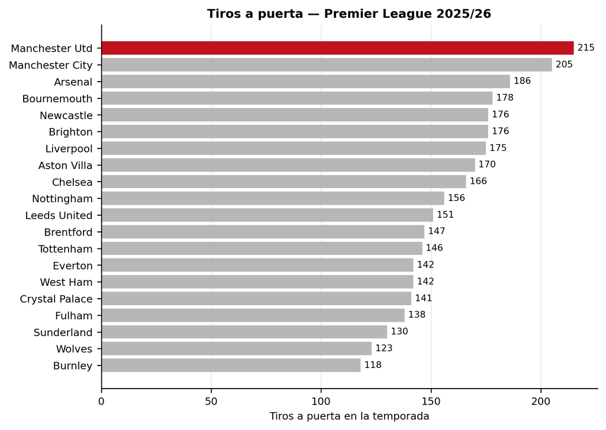

Figura 1: Tiros a puerta por equipo. El United lidera la liga en generación de remate franco.

```python
d = liga.sort_values("shots_on_target")
fig, ax = plt.subplots(figsize=(7, 5))
ax.barh(d["team"], d["shots_on_target"], color=resaltar(d["team"]))
ax.set_xlabel("Tiros a puerta en la temporada")
ax.set_title("Tiros a puerta — Premier League 2025/26")
ax.grid(axis="y", visible=False)
for i, (_, r) in enumerate(d.iterrows()):
    ax.annotate(f"{int(r['shots_on_target'])}", (r["shots_on_target"], i),
                xytext=(3, 0), textcoords="offset points", va="center", fontsize=7.5)
fig.tight_layout()
plt.show()
```

# 3 Eficiencia: dónde se ganó y dónde se perdió la temporada

## 3.1 El coste de rematar mucho y mal

Si el United lideró la liga en tiros a puerta pero terminó tercero en goles, la diferencia está en la conversión. Y ahí el dato es incómodo.

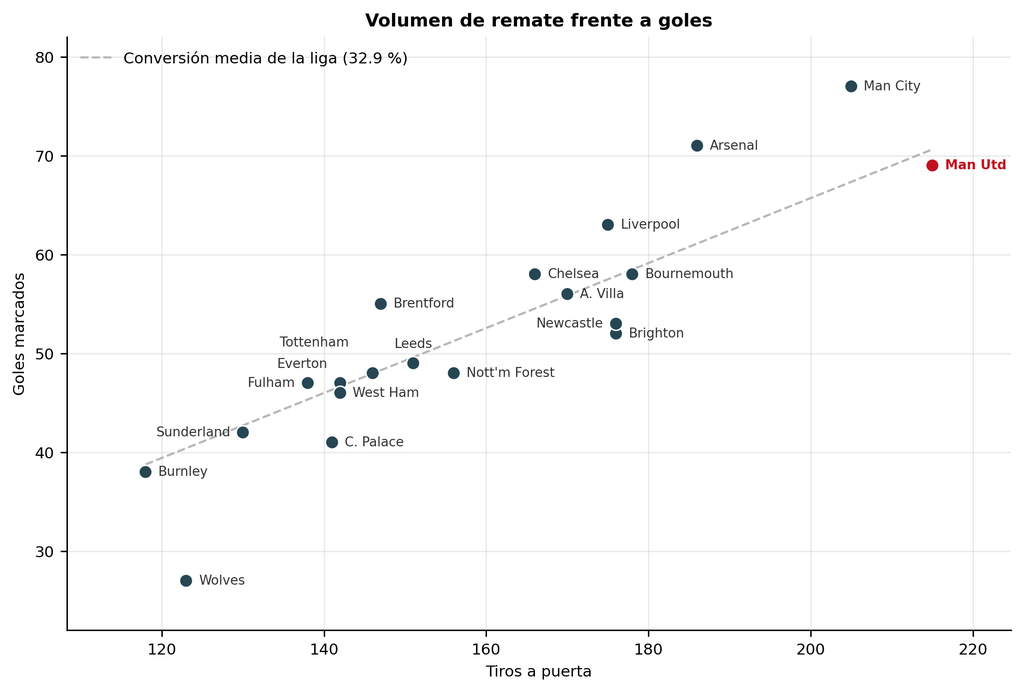

Figura 2: Tiros a puerta contra goles marcados. La línea es el rendimiento medio de la liga; por debajo de ella se convierte peor de lo esperado.

```python
fig, ax = plt.subplots(figsize=(8, 5.4))
ax.scatter(liga["shots_on_target"], liga["goals_for"],
           s=55, color=[ROJO if t == UTD else AZUL for t in liga["team"]],
           zorder=3, edgecolor="white", linewidth=0.8)

# Recta de conversión media de la liga
tasa_media = liga["goals_for"].sum() / liga["shots_on_target"].sum()
xs = np.array([liga["shots_on_target"].min(), liga["shots_on_target"].max()])
ax.plot(xs, xs * tasa_media, "--", color=GRIS, linewidth=1.2, zorder=1,
        label=f"Conversión media de la liga ({tasa_media*100:.1f} %)")

# Se etiquetan los 20 equipos; el United primero para asegurarle sitio, y el
# resto de mayor a menor distancia respecto a la recta media, que es lo que
# hace interesante a un punto en este gráfico.
d = liga.assign(desvio=(liga["goals_for"] - liga["shots_on_target"] * tasa_media).abs())
d = pd.concat([d[d["team"] == UTD], d[d["team"] != UTD].sort_values("desvio", ascending=False)])

etiquetar(ax, d["shots_on_target"].values, d["goals_for"].values,
          [CORTO.get(t, t) for t in d["team"]],
          colores=[ROJO if t == UTD else "#333333" for t in d["team"]],
          negritas=[t == UTD for t in d["team"]])

ax.set_xlabel("Tiros a puerta")
ax.set_ylabel("Goles marcados")
ax.set_title("Volumen de remate frente a goles")
ax.margins(x=0.10, y=0.10)
ax.legend(frameon=False, loc="upper left")
fig.tight_layout()
plt.show()
```

Tabla 3: Conversión de tiros a puerta, los 20 equipos. La última columna es la métrica que publica FBref, que excluye penaltis; la penúltima incluye todos los goles.

| # | Equipo | Tiros a puerta | Goles | Conversión % | G sin penalti / tiro a puerta |
| --- | --- | --- | --- | --- | --- |
| 1 | Arsenal | 186 | 71 | 38.17 | 0.34 |
| 2 | Manchester City | 205 | 77 | 37.56 | 0.35 |
| 3 | Brentford | 147 | 55 | 37.41 | 0.31 |
| 4 | Liverpool | 175 | 63 | 36.00 | 0.34 |
| 5 | Chelsea | 166 | 58 | 34.94 | 0.30 |
| 6 | Fulham | 138 | 47 | 34.06 | 0.28 |
| 7 | Everton | 142 | 47 | 33.10 | 0.30 |
| 8 | Aston Villa | 170 | 56 | 32.94 | 0.31 |
| 9 | Tottenham | 146 | 48 | 32.88 | 0.32 |
| 10 | Bournemouth | 178 | 58 | 32.58 | 0.29 |
| 11 | Leeds United | 151 | 49 | 32.45 | 0.28 |
| 12 | West Ham | 142 | 46 | 32.39 | 0.29 |
| 13 | Sunderland | 130 | 42 | 32.31 | 0.26 |
| 14 | Burnley | 118 | 38 | 32.20 | 0.28 |
| 15 | Manchester Utd | 215 | 69 | 32.09 | 0.29 |
| 16 | Nottingham | 156 | 48 | 30.77 | 0.28 |
| 17 | Newcastle | 176 | 53 | 30.11 | 0.27 |
| 18 | Brighton | 176 | 52 | 29.55 | 0.27 |
| 19 | Crystal Palace | 141 | 41 | 29.08 | 0.23 |
| 20 | Wolves | 123 | 27 | 21.95 | 0.19 |

**AdvertenciaDos definiciones de gol conviven en estos datos**

FBref publica **66 goles** del United y la clasificación, **69**. No es un error: la tabla de plantilla suma sólo los goles anotados por jugadores del equipo, mientras que la clasificación incluye los **3 goles en propia puerta a favor**. Además, `goals_per_shot_on_target` **excluye los penaltis**: los 0,29 del United salen de (66 − 4) ÷ 215.

En este documento se usa el criterio de la clasificación —69 goles, todo incluido— para cualquier cálculo propio, y la columna de FBref se conserva etiquetada como lo que es. Mezclar ambas en una misma comparación es el error fácil aquí.

```python
goles_esperados = utd["shots_on_target"] * tasa_media
brecha = utd["goals_for"] - goles_esperados
print(f"Con {int(utd['shots_on_target'])} tiros a puerta y la conversión media de "
      f"la liga ({tasa_media*100:.1f} %), al United le habrían correspondido "
      f"**{goles_esperados:.0f} goles**. Marcó **{int(utd['goals_for'])}**: "
      f"**{brecha:+.0f}** respecto a lo esperado por volumen.\n\n"
      f"El City marcó {int(liga.loc[liga['team']=='Manchester City','goals_for'].iloc[0])} "
      f"con {int(liga.loc[liga['team']=='Manchester City','shots_on_target'].iloc[0])} "
      f"tiros a puerta; el Arsenal, "
      f"{int(liga.loc[liga['team']=='Arsenal','goals_for'].iloc[0])} con "
      f"{int(liga.loc[liga['team']=='Arsenal','shots_on_target'].iloc[0])}.")
```

Con 215 tiros a puerta y la conversión media de la liga (32.9 %), al United le habrían correspondido **71 goles**. Marcó **69**: **-2** respecto a lo esperado por volumen.

El City marcó 77 con 205 tiros a puerta; el Arsenal, 71 con 186.

Con la conversión del Arsenal (38.2 % en vez del 32.1 % del United) esos 215 tiros a puerta habrían dado **82 goles** en lugar de 69. Con la del City, **81**.

Ésta es la lectura central de la temporada: **el United generó más remate franco que nadie y lo aprovechó por debajo de la media de la liga**. No es un problema de creación, es de definición: el margen está en quién remata y desde dónde, no en llegar más veces.

## 3.2 La portería como agujero

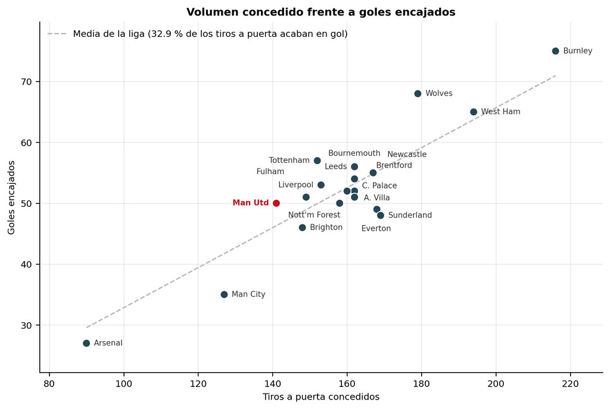

Figura 3: Tiros a puerta concedidos frente a goles encajados. Los equipos por encima de la línea encajan más de lo que su volumen concedido haría esperar.

```python
fig, ax = plt.subplots(figsize=(8, 5.4))
ax.scatter(liga["shots_on_target_contra"], liga["goals_against"],
           s=55, color=[ROJO if t == UTD else AZUL for t in liga["team"]],
           zorder=3, edgecolor="white", linewidth=0.8)

tasa_def = liga["goals_against"].sum() / liga["shots_on_target_contra"].sum()
xs = np.array([liga["shots_on_target_contra"].min(), liga["shots_on_target_contra"].max()])
ax.plot(xs, xs * tasa_def, "--", color=GRIS, linewidth=1.2, zorder=1,
        label=f"Media de la liga ({tasa_def*100:.1f} % de los tiros a puerta acaban en gol)")

d = liga.assign(desvio=(liga["goals_against"] - liga["shots_on_target_contra"] * tasa_def).abs())
d = pd.concat([d[d["team"] == UTD], d[d["team"] != UTD].sort_values("desvio", ascending=False)])

etiquetar(ax, d["shots_on_target_contra"].values, d["goals_against"].values,
          [CORTO.get(t, t) for t in d["team"]],
          colores=[ROJO if t == UTD else "#333333" for t in d["team"]],
          negritas=[t == UTD for t in d["team"]])

ax.set_xlabel("Tiros a puerta concedidos")
ax.set_ylabel("Goles encajados")
ax.set_title("Volumen concedido frente a goles encajados")
ax.margins(x=0.10, y=0.10)
ax.legend(frameon=False, loc="upper left")
fig.tight_layout()
plt.show()
```

**Definición 1**

```python
gc_esperados = utd["shots_on_target_contra"] * tasa_def
print(f"El United concedió sólo **{int(utd['shots_on_target_contra'])} tiros a "
      f"puerta**, el tercer registro más bajo de la liga tras Arsenal (89) y City "
      f"(126). Por ese volumen le habrían correspondido **{gc_esperados:.0f} goles "
      f"en contra**; encajó **{int(utd['goals_against'])}**, "
      f"**{utd['goals_against'] - gc_esperados:+.0f}** de más.\n\n"
      f"Con el porcentaje de paradas del City (72,2 %) en lugar del suyo "
      f"({utd['gk_save_pct']:.1f} %), el United habría encajado unos "
      f"{utd['shots_on_target_contra'] * (1 - 0.722):.0f} goles en vez de 50.")
```

Con el porcentaje de paradas del City (72,2 %) en lugar del suyo (64.8 %), el United habría encajado unos 39 goles en vez de 50.

El bloque defensivo funcionó —muy pocos tiros a puerta concedidos—, pero la portería no sostuvo ese trabajo. **Es el desajuste más grande del equipo**: tercera mejor defensa por volumen concedido y sólo sexta por goles encajados, con el puesto 16 de 20 en porcentaje de paradas.

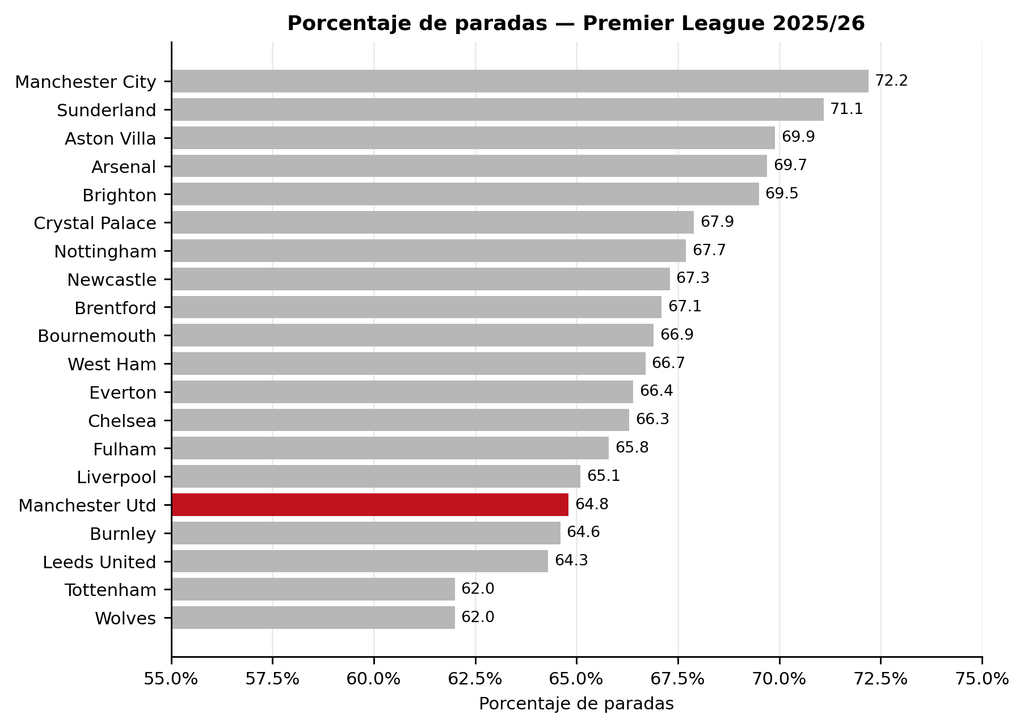

Figura 4: Porcentaje de paradas por equipo. El United queda en el puesto 16 de 20 pese a ser tercero en la clasificación.

```python
d = liga.sort_values("gk_save_pct")
fig, ax = plt.subplots(figsize=(7, 5))
ax.barh(d["team"], d["gk_save_pct"], color=resaltar(d["team"]))
ax.set_xlabel("Porcentaje de paradas")
ax.set_xlim(55, 75)
ax.xaxis.set_major_formatter(PercentFormatter())
ax.set_title("Porcentaje de paradas — Premier League 2025/26")
ax.grid(axis="y", visible=False)
for i, (_, r) in enumerate(d.iterrows()):
    ax.annotate(f"{r['gk_save_pct']:.1f}", (r["gk_save_pct"], i),
                xytext=(3, 0), textcoords="offset points", va="center", fontsize=7.5)
fig.tight_layout()
plt.show()
```

# 4 La temporada partido a partido

```python
pl = (united_partidos.query("comp == 'Premier League'")
                     .sort_values("date")
                     .reset_index(drop=True))
pl["jornada"] = pl.index + 1
pl["puntos"] = pl["result"].map({"W": 3, "D": 1, "L": 0})
pl["puntos_acum"] = pl["puntos"].cumsum()
pl["dif_acum"] = (pl["goals_for"] - pl["goals_against"]).cumsum()
pl["forma_5"] = pl["puntos"].rolling(5).mean()

# El cambio de sistema: 3-4-3 hasta la jornada 18, 4-2-3-1 a partir de ahí
pl["sistema"] = np.where(pl["jornada"] <= 17, "3-4-3", "4-2-3-1 (mayoritario)")
```

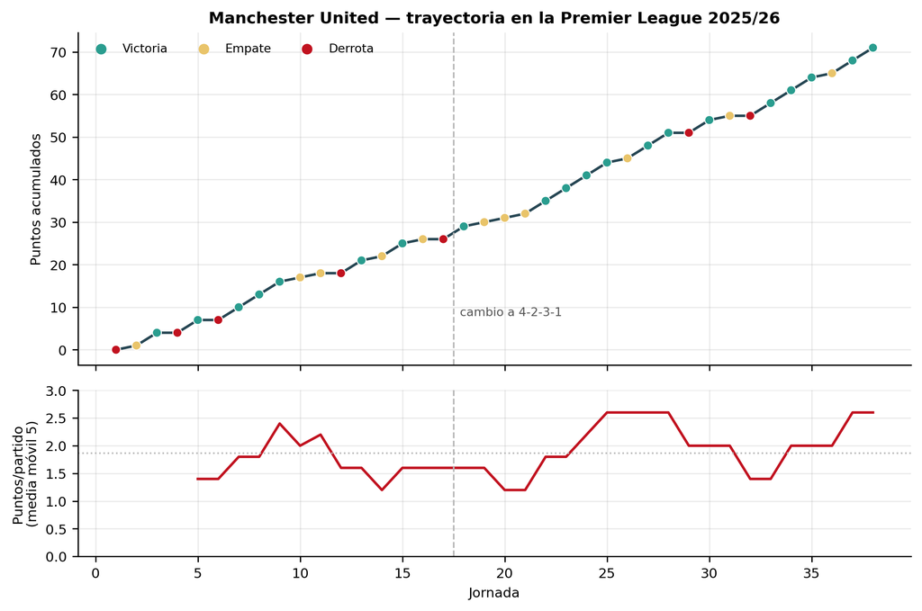

Figura 5: Puntos acumulados y forma en ventana de cinco partidos. La línea vertical marca el cambio de sistema tras la jornada 17.

```python
fig, (ax1, ax2) = plt.subplots(2, 1, figsize=(8, 5.4), sharex=True,
                               gridspec_kw={"height_ratios": [2, 1]})

colores = {"W": VERDE, "D": AMBAR, "L": ROJO}
ax1.plot(pl["jornada"], pl["puntos_acum"], color=AZUL, linewidth=1.6, zorder=2)
ax1.scatter(pl["jornada"], pl["puntos_acum"],
            c=[colores[r] for r in pl["result"]], s=32, zorder=3,
            edgecolor="white", linewidth=0.6)
ax1.set_ylabel("Puntos acumulados")
ax1.set_title("Manchester United — trayectoria en la Premier League 2025/26")
ax1.axvline(17.5, color=GRIS, linestyle="--", linewidth=1)
ax1.annotate("cambio a 4-2-3-1", (17.5, 8), xytext=(4, 0),
             textcoords="offset points", fontsize=7.5, color="#555")
for res, col in colores.items():
    ax1.scatter([], [], c=col, label={"W": "Victoria", "D": "Empate", "L": "Derrota"}[res], s=32)
ax1.legend(frameon=False, loc="upper left", ncol=3, fontsize=7.5)

ax2.plot(pl["jornada"], pl["forma_5"], color=ROJO, linewidth=1.6)
ax2.axhline(pl["puntos"].mean(), color=GRIS, linestyle=":", linewidth=1)
ax2.axvline(17.5, color=GRIS, linestyle="--", linewidth=1)
ax2.set_ylabel("Puntos/partido\n(media móvil 5)")
ax2.set_xlabel("Jornada")
ax2.set_ylim(0, 3)

fig.tight_layout()
plt.show()
```

Tabla 4: Rendimiento antes y después del cambio de dibujo tras la jornada 17.

| Sistema | PJ | Pts | Pts/partido | GF | GC | Posesión media |
| --- | --- | --- | --- | --- | --- | --- |
| 3-4-3 | 17 | 26 | 1.53 | 31 | 28 | 54.59 |
| 4-2-3-1 (mayoritario) | 21 | 45 | 2.14 | 38 | 22 | 49.76 |

El equipo cambió de 3-4-3 a 4-2-3-1 en la jornada 18 (26 de diciembre, 1-0 al Newcastle) y el rendimiento cambió con él. **Merece comprobarse si el cambio es causa o coincidencia**: el calendario de la segunda vuelta y la recuperación de efectivos son explicaciones alternativas que estos datos no descartan.

Tabla 5: Rendimiento como local y como visitante.

| Condición | PJ | Pts | Pts/partido | GF | GC | Posesión media |
| --- | --- | --- | --- | --- | --- | --- |
| Visitante | 19 | 29 | 1.53 | 30 | 26 | 52.47 |
| Local | 19 | 42 | 2.21 | 39 | 24 | 51.37 |

# 5 Plantilla completa

Tabla 6: Plantilla del United en Premier League 2025/26 (jugadores con al menos 90 minutos).

| Jugador | Pos | Edad | PJ | Tit | Min | G | A | TA | TR | G/90 | A/90 |
| --- | --- | --- | --- | --- | --- | --- | --- | --- | --- | --- | --- |
| Luke Shaw | DF | 30 | 38 | 38 | 3219 | 1 | 1 | 9 | 0 | 0.03 | 0.03 |
| Bruno Fernandes | MF | 30 | 35 | 35 | 3063 | 9 | 21 | 5 | 0 | 0.26 | 0.62 |
| Senne Lammens | GK | 23 | 32 | 32 | 2880 | 0 | 0 | 0 | 0 | 0.00 | 0.00 |
| Diogo Dalot | DFMF | 26 | 34 | 29 | 2614 | 1 | 3 | 5 | 0 | 0.03 | 0.10 |
| Bryan Mbeumo | MFFW | 25 | 33 | 31 | 2609 | 11 | 3 | 4 | 0 | 0.38 | 0.10 |
| Casemiro | MF | 33 | 34 | 33 | 2571 | 9 | 2 | 11 | 1 | 0.32 | 0.07 |
| Matheus Cunha | MFFW | 26 | 33 | 29 | 2494 | 10 | 2 | 4 | 0 | 0.36 | 0.07 |
| Amad Diallo | MF | 23 | 32 | 27 | 2341 | 2 | 3 | 2 | 0 | 0.08 | 0.12 |
| Leny Yoro | DF | 19 | 32 | 18 | 1740 | 0 | 0 | 1 | 0 | 0.00 | 0.00 |
| Kobbie Mainoo | MF | 20 | 28 | 16 | 1662 | 1 | 2 | 2 | 0 | 0.05 | 0.11 |
| Harry Maguire | DF | 32 | 23 | 19 | 1653 | 1 | 2 | 3 | 1 | 0.05 | 0.11 |
| Benjamin Šeško | FW | 22 | 30 | 17 | 1643 | 11 | 1 | 2 | 0 | 0.60 | 0.05 |
| Patrick Dorgu | MF | 20 | 26 | 15 | 1449 | 4 | 4 | 5 | 0 | 0.25 | 0.25 |
| Lisandro Martínez | DF | 27 | 18 | 13 | 1233 | 0 | 0 | 0 | 1 | 0.00 | 0.00 |
| Matthijs de Ligt | DF | 25 | 13 | 13 | 1170 | 1 | 0 | 0 | 0 | 0.08 | 0.00 |
| Mason Mount | MF | 26 | 23 | 12 | 1017 | 3 | 0 | 2 | 0 | 0.27 | 0.00 |
| Noussair Mazraoui | DFMF | 27 | 20 | 11 | 985 | 0 | 0 | 3 | 0 | 0.00 | 0.00 |
| Ayden Heaven | DF | 18 | 17 | 11 | 924 | 0 | 1 | 2 | 0 | 0.00 | 0.10 |
| Manuel Ugarte | MF | 24 | 22 | 8 | 887 | 0 | 0 | 1 | 0 | 0.00 | 0.00 |
| Joshua Zirkzee | FWMF | 24 | 24 | 5 | 626 | 2 | 1 | 3 | 0 | 0.29 | 0.14 |
| Altay Bayındır | GK | 27 | 6 | 6 | 540 | 0 | 0 | 0 | 0 | 0.00 | 0.00 |
| Jack Fletcher | MF | 18 | 3 | 0 | 108 | 0 | 0 | 0 | 0 | 0.00 | 0.00 |

## 5.1 Reparto de minutos

Tabla 7: Uso de la plantilla. «Completos» son partidos jugados de principio a fin.

| Jugador | Pos | PJ | Titular | Completos | Desde banquillo | Min | % de minutos | Pts/partido | +/− |
| --- | --- | --- | --- | --- | --- | --- | --- | --- | --- |
| Luke Shaw | DF | 38 | 38 | 23 | 0 | 3219 | 94.10 | 1.87 | 21 |
| Bruno Fernandes | MF | 35 | 35 | 29 | 0 | 3063 | 89.60 | 1.89 | 20 |
| Senne Lammens | GK | 32 | 32 | 32 | 0 | 2880 | 84.20 | 2.00 | 23 |
| Diogo Dalot | DFMF | 34 | 29 | 22 | 5 | 2614 | 76.40 | 1.88 | 18 |
| Bryan Mbeumo | MFFW | 33 | 31 | 13 | 2 | 2609 | 76.30 | 1.97 | 21 |
| Casemiro | MF | 34 | 33 | 13 | 1 | 2571 | 75.20 | 1.97 | 24 |
| Matheus Cunha | MFFW | 33 | 29 | 16 | 4 | 2494 | 72.90 | 1.88 | 13 |
| Amad Diallo | MF | 32 | 27 | 17 | 5 | 2341 | 68.50 | 2.03 | 19 |
| Leny Yoro | DF | 32 | 18 | 9 | 14 | 1740 | 50.90 | 1.72 | -5 |
| Kobbie Mainoo | MF | 28 | 16 | 14 | 12 | 1662 | 48.60 | 2.21 | 16 |
| Harry Maguire | DF | 23 | 19 | 13 | 4 | 1653 | 48.30 | 2.04 | 17 |
| Benjamin Šeško | FW | 30 | 17 | 8 | 13 | 1643 | 48.00 | 1.80 | 7 |
| Patrick Dorgu | MF | 26 | 15 | 10 | 11 | 1449 | 42.40 | 1.73 | 2 |
| Lisandro Martínez | DF | 18 | 13 | 11 | 5 | 1233 | 36.10 | 1.89 | 10 |
| Matthijs de Ligt | DF | 13 | 13 | 13 | 0 | 1170 | 34.20 | 1.62 | 1 |
| Mason Mount | MF | 23 | 12 | 3 | 11 | 1017 | 29.70 | 1.87 | 4 |
| Noussair Mazraoui | DFMF | 20 | 11 | 3 | 9 | 985 | 28.80 | 2.00 | 9 |
| Ayden Heaven | DF | 17 | 11 | 7 | 6 | 924 | 27.00 | 2.00 | 5 |
| Manuel Ugarte | MF | 22 | 8 | 3 | 14 | 887 | 25.90 | 1.55 | -11 |
| Joshua Zirkzee | FWMF | 24 | 5 | 2 | 19 | 626 | 18.30 | 1.79 | 1 |
| Altay Bayındır | GK | 6 | 6 | 6 | 0 | 540 | 15.80 | 1.17 | -4 |

**TipSí: Luke Shaw jugó los 38 partidos**

El dato llama la atención por su historial de lesiones, pero FBref es internamente consistente y admite comprobación: **38 partidos, 38 titularidades, 3 219 minutos**, que son el **94,1 %** de los 3 420 posibles. La cifra encaja porque no jugó los 38 completos, sólo **23**: fue sustituido en los otros 15, promediando 85 minutos por partido. No entró ni una vez desde el banquillo y no figura como suplente sin utilizar en ninguna jornada.

Fue el único jugador de la plantilla presente en los 38 partidos de liga. El segundo en minutos es Bruno Fernandes (3 063 en 35 partidos), que sí se perdió tres.

## 5.2 Producción ajustada por minutos

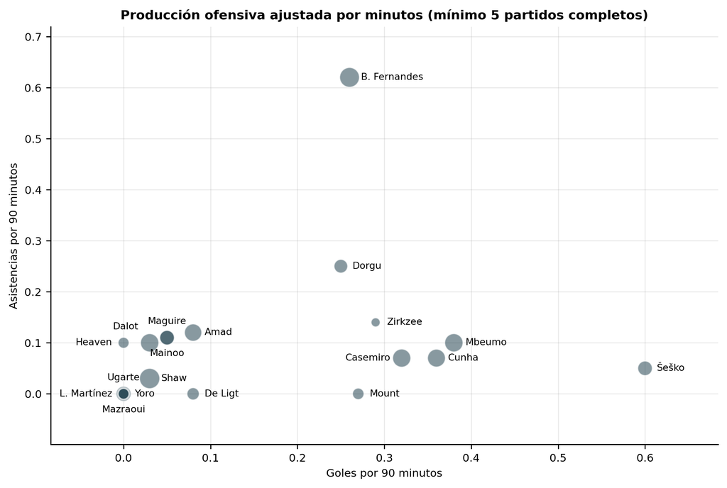

Figura 6: Goles y asistencias por 90 minutos. El tamaño del punto es proporcional a los minutos jugados.

```python
d = united_plantilla.query("minutes_90s >= 5 and position != 'GK'").copy()
# Etiqueta corta: apellido, con las excepciones donde el apellido solo no basta.
EXCEPCIONES = {"Matthijs de Ligt": "De Ligt", "Bruno Fernandes": "B. Fernandes",
               "Lisandro Martínez": "L. Martínez", "Amad Diallo": "Amad"}
d["etiqueta"] = [EXCEPCIONES.get(p, p.split()[-1]) for p in d["player"]]

fig, ax = plt.subplots(figsize=(8, 5.4))
ax.scatter(d["goals_per90"], d["assists_per90"],
           s=d["minutes_90s"] * 7, alpha=0.55, color=AZUL,
           edgecolor="white", linewidth=0.8, zorder=3)

# Se etiqueta a todos, empezando por los de mayor producción total para que sean
# ellos quienes se queden con el hueco si hay disputa.
d = d.sort_values("goals_assists_per90", ascending=False)
etiquetar(ax, d["goals_per90"].values, d["assists_per90"].values,
          d["etiqueta"].tolist(), fontsize=7.5, dist=9)

ax.set_xlabel("Goles por 90 minutos")
ax.set_ylabel("Asistencias por 90 minutos")
ax.set_title("Producción ofensiva ajustada por minutos (mínimo 5 partidos completos)")
ax.margins(x=0.14, y=0.16)
fig.tight_layout()
plt.show()
```

```python
s = united_plantilla.set_index("player")
sesko, mbeumo = s.loc["Benjamin Šeško"], s.loc["Bryan Mbeumo"]
print(f"**Šeško y Mbeumo empataron a 11 goles con cargas muy distintas.** "
      f"Šeško los marcó en {sesko['minutes']:,.0f} minutos "
      f"({sesko['games_starts']:.0f} titularidades) y Mbeumo en "
      f"{mbeumo['minutes']:,.0f} ({mbeumo['games_starts']:.0f}). "
      f"Por 90 minutos: **{sesko['goals_per90']:.2f} contra "
      f"{mbeumo['goals_per90']:.2f}**, una diferencia del "
      f"{(sesko['goals_per90']/mbeumo['goals_per90']-1)*100:.0f} % a favor de Šeško, "
      f"que fue además el jugador más eficiente de la plantilla.")
```

**Šeško y Mbeumo empataron a 11 goles con cargas muy distintas.** Šeško los marcó en 1,643 minutos (17 titularidades) y Mbeumo en 2,609 (31). Por 90 minutos: **0.60 contra 0.38**, una diferencia del 58 % a favor de Šeško, que fue además el jugador más eficiente de la plantilla.

Con los datos de Marca esta diferencia era invisible: la ficha daba medias de 0,37 y 0,33, sugiriendo que Šeško había jugado apenas tres partidos menos. En realidad jugó **casi mil minutos menos** y fue, con diferencia, el delantero más rentable por minuto del equipo.

## 5.3 Bruno Fernandes, otra vez el eje

Tabla 8: Peso de Bruno Fernandes en la producción del equipo.

| Métrica | Bruno | Equipo | % del equipo |
| --- | --- | --- | --- |
| Asistencias | 21 | 46 | 45.65 |
| Centros | 181 | 639 | 28.33 |
| Goles | 9 | 66 | 13.64 |
| Penaltis lanzados | 6 | 6 | 100.00 |

# 6 Síntesis

Tabla 9: El United en una tabla.

[output not shown]

La temporada se sostiene sobre una asimetría clara: **el United fue el mejor equipo de la liga generando remate franco y uno de los peores aprovechándolo, tanto en ataque como bajo palos**. Terminó tercero en la clasificación con el mayor volumen de tiros a puerta de la Premier y el puesto 16 de 20 en porcentaje de paradas.

Es un perfil poco común y con una implicación directa: el margen de mejora no está en crear más ocasiones —ya lidera— sino en definirlas y en la portería.

# 7 Líneas de análisis abiertas

Todos los datos necesarios para las siete primeras ya están cargados.

Tabla 10: Candidatos para las siguientes secciones.

| # | Análisis | Datos | Qué respondería |
| --- | --- | --- | --- |
| 1 | Perfil del United contra la media de la liga (z-scores por métrica) | Listos | En qué es realmente atípico |
| 2 | Ranking de eficiencia ofensiva y defensiva de los 20 equipos | Listos | Si el desajuste del United es único |
| 3 | Rendimiento contra rivales del *top 6* frente al resto | Listos | Si compitió contra los grandes |
| 4 | Efecto del cambio de sistema, controlando por dificultad de rival | Listos | Si el 4-2-3-1 explica la segunda vuelta |
| 5 | Comparación directa con City y Arsenal, métrica a métrica | Listos | Qué le faltó para pelear el título |
| 6 | Reparto de minutos y dependencia de titulares | Listos | Fondo de armario y rotación |
| 7 | Relación entre posesión y resultado, partido a partido | Listos | Si le convino tener el balón |
| 8 | xG contra goles reales | Requiere Understat o FBref avanzado | Si la mala definición fue mala suerte |
| 9 | Comparación con temporadas anteriores del United | Requiere descargar 2019/20–2024/25 | Magnitud real de la mejora |

**NotaReproducibilidad**

Los CSV de `datos/` se generaron desde FBref el 16 de agosto de 2026. El script `scripts/descargar_fbref.py` automatiza la descarga, aunque FBref responde 403 a peticiones directas desde este entorno: los datos actuales se extrajeron del DOM con el navegador. Todas las cifras derivadas se calculan en este documento.